# LDA_Salary

pg606@scarletmail.rutgers.edu

2024-04-26

```r
library(MASS)
library(ggplot2)
library(memisc)
library(ROCR)
library(dplyr)
library(klaR)
wdbc <- read.csv("/Users/Prateekg/Documents/MVA/Salary_multiple_regression.csv")
dim(wdbc)
```

```
## [1] 10 14
```

```r
str(wdbc)
```

```
## 'data.frame':    10 obs. of  14 variables:
##  $ job_title         : chr  "AI Architect" "AI Developer" "AI Engineer" "AI Scientist" ...
##  $ job_category      : chr  "Machine Learning and AI" "Machine Learning and AI" "Machine Learning and AI" "Machine Learning and AI" ...
##  $ salary_currency   : chr  "USD" "EUR" "USD" "USD" ...
##  $ employee_residence: chr  "United States" "France" "Czech Republic" "Ghana" ...
##  $ experience_level  : chr  "Senior" "Senior" "Mid-level" "Mid-level" ...
##  $ employment_type   : chr  "Full-time" "Full-time" "Contract" "Full-time" ...
##  $ work_setting      : chr  "Remote" "Hybrid" "Remote" "In-person" ...
##  $ company_location  : chr  "United States" "France" "Canada" "Ghana" ...
##  $ company_size      : chr  "M" "M" "L" "S" ...
##  $ Salary_Level      : chr  "High" "High" "Low" "Low" ...
##  $ work_year         : int  2020 2016 2018 2017 2023 2021 2022 2015 2013 2014
##  $ salary            : int  305100 150000 50000 30000 140000 423000 222200 258000 100000 160000
##  $ salary_in_usd     : int  305100 161952 50000 30000 140000 423000 222200 258000 100000 160000
##  $ salaryLevel       : int  1 1 0 0 0 1 1 1 0 1
```

```r
features <- c("Category", "Currency", "EmpResidence","ExpLevel", "EmpType", "WorkSetting", "location", "size", "level", "year", "salary", "USD", "SalaryLevel")
names(wdbc) <- c("Title", "Category", "Currency", "EmpResidence","ExpLevel", "EmpType", "WorkSetting", "location", "size", "level", "year", "salary", "USD", "SalaryLevel")
```

#Model development

```r
wdbc.data <- as.matrix(wdbc[,c(11:13)])
row.names(wdbc.data) <- wdbc$Title
wdbc_raw <- cbind(wdbc.data, as.numeric(as.factor(wdbc$SalaryLevel))-1)
colnames(wdbc_raw)[4] <- "EmpSalaryLevel"
smp_size_raw <- floor(0.75 * nrow(wdbc_raw))
train_ind_raw <- sample(nrow(wdbc_raw), size = smp_size_raw)
train_raw.df <- as.data.frame(wdbc_raw[train_ind_raw, ])
test_raw.df <- as.data.frame(wdbc_raw[-train_ind_raw, ])
wdbc_raw.lda <- lda(formula = train_raw.df$EmpSalaryLevel ~ ., data = train_raw.df)
wdbc_raw.lda
```

```
## Call:
## lda(train_raw.df$EmpSalaryLevel ~ ., data = train_raw.df)
##
## Prior probabilities of groups:
##         0         1
## 0.2857143 0.7142857
##
## Group means:
##     year salary      USD
## 0 2020.5  95000  95000.0
## 1 2017.2 259220 261610.4
##
## Coefficients of linear discriminants:
##                  LD1
## year   -0.6900637204
## salary -0.0001924704
## USD     0.0002178038
```

Split the dataset into training and testing sets. Examine the output of the trained LDA model to understand the prior probabilities of groups, group means, and coefficients of linear discriminants. Interpret the coefficients to understand the impact of each predictor on the salary level prediction.

#Model Acceptance

```r
summary(wdbc_raw.lda)
```

```
##         Length Class  Mode
## prior   2      -none- numeric
## counts  2      -none- numeric
## means   6      -none- numeric
## scaling 3      -none- numeric
## lev     2      -none- character
## svd     1      -none- numeric
## N       1      -none- numeric
## call    3      -none- call
## terms   3      terms  call
## xlevels 0      -none- list
```

```r
print(wdbc_raw.lda)
```

```
## Call:
## lda(train_raw.df$EmpSalaryLevel ~ ., data = train_raw.df)
##
## Prior probabilities of groups:
##         0         1
## 0.2857143 0.7142857
##
## Group means:
##     year salary      USD
## 0 2020.5  95000  95000.0
## 1 2017.2 259220 261610.4
##
## Coefficients of linear discriminants:
##                  LD1
## year   -0.6900637204
## salary -0.0001924704
## USD     0.0002178038
```

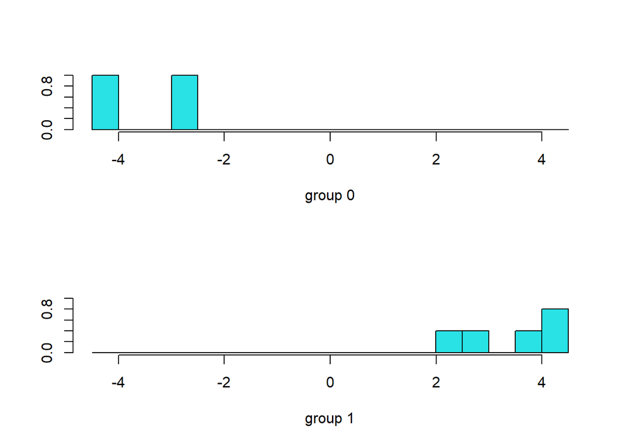

```r
plot(wdbc_raw.lda)
```

```r
wdbc_raw.lda.predict_train <- predict(wdbc_raw.lda, newdata = train_raw.df)
y<-wdbc_raw.lda.predict_train$class
wdbc_raw.lda.predict_train$x
```

[output not shown]

```r
table(y,train_raw.df$EmpSalaryLevel)
```

```
##
## y   0 1
##   0 2 0
##   1 0 5
```

```r
wdbc_raw.lda.predict <- predict(wdbc_raw.lda, newdata = test_raw.df)
y<-wdbc_raw.lda.predict$class
wdbc_raw.lda.predict$x
```

```
##                            LD1
## AI Scientist        -4.2015153
## Applied Scientist   -2.7827583
## Azure Data Engineer  0.3320762
```

```r
table(y,test_raw.df$EmpSalaryLevel)
```

```
##
## y   0 1
##   0 1 1
##   1 1 0
```

#Residual Analysis

```r
# Get the posteriors as a dataframe.
wdbc_raw.lda.predict.posteriors <- as.data.frame(wdbc_raw.lda.predict$posterior)
```

Residual analysis to refine the model, such as adjusting predictor variables, exploring different modeling techniques, or collecting additional data.

#Prediction

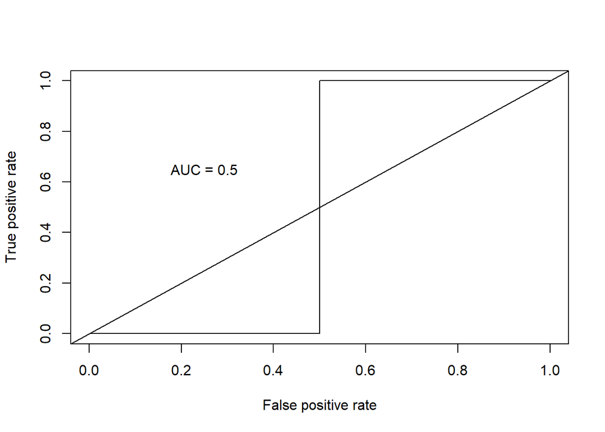

```r
pred <- prediction(wdbc_raw.lda.predict.posteriors[1:3,2], test_raw.df$EmpSalaryLevel)


roc.perf = performance(pred, measure = "tpr", x.measure = "fpr")
auc.train <- performance(pred, measure = "auc")
auc.train <- auc.train@y.values
plot(roc.perf)
abline(a=0, b= 1)
text(x = .25, y = .65 ,paste("AUC = ", round(auc.train[[1]],3), sep = ""))
```

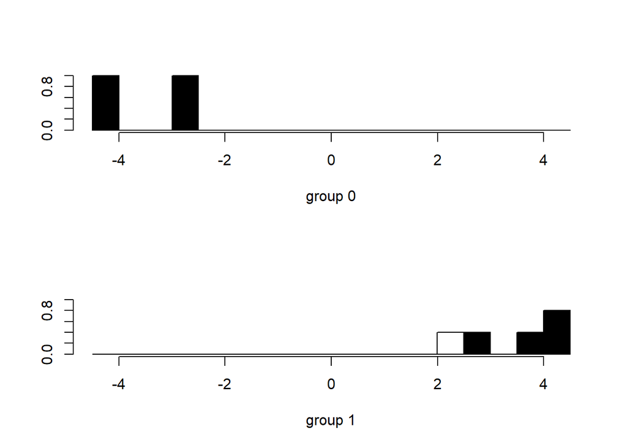

```r
plot(wdbc_raw.lda, col = as.integer(train_raw.df$EmpSalaryLevel))
```

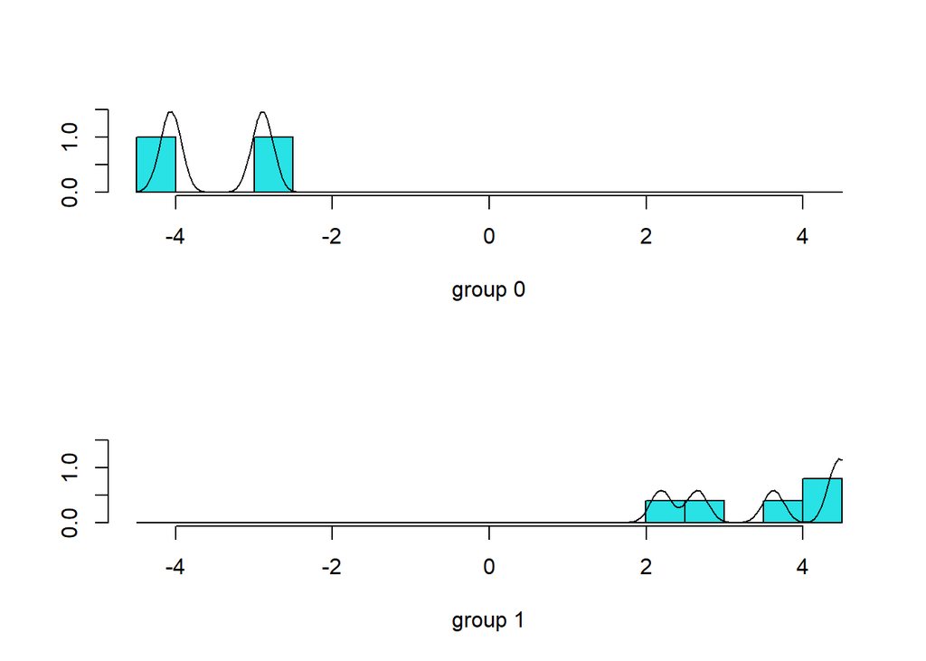

```r
plot(wdbc_raw.lda, dimen = 1, type = "b")
```

```r
m <- manova(cbind(wdbc$year,wdbc$salary,wdbc$USD)~wdbc$SalaryLevel,data=wdbc)
summary(m,test="Wilks")
```

```
##                  Df   Wilks approx F num Df den Df  Pr(>F)
## wdbc$SalaryLevel  1 0.29088   4.8758      3      6 0.04757 *
## Residuals         8
## ---
## Signif. codes:  0 '***' 0.001 '**' 0.01 '*' 0.05 '.' 0.1 ' ' 1
```

```r
summary(m,test="Pillai")
```

```
##                  Df  Pillai approx F num Df den Df  Pr(>F)
## wdbc$SalaryLevel  1 0.70912   4.8758      3      6 0.04757 *
## Residuals         8
## ---
## Signif. codes:  0 '***' 0.001 '**' 0.01 '*' 0.05 '.' 0.1 ' ' 1
```

```r
summary.aov(m)
```

```
##  Response 1 :
##                  Df Sum Sq Mean Sq F value Pr(>F)
## wdbc$SalaryLevel  1   0.15   0.150   0.011 0.9189
## Residuals         8 108.75  13.594
##
##  Response 2 :
##                  Df     Sum Sq    Mean Sq F value  Pr(>F)
## wdbc$SalaryLevel  1 7.1871e+10 7.1871e+10  9.7048 0.01433 *
## Residuals         8 5.9246e+10 7.4058e+09
## ---
## Signif. codes:  0 '***' 0.001 '**' 0.01 '*' 0.05 '.' 0.1 ' ' 1
##
##  Response 3 :
##                  Df     Sum Sq    Mean Sq F value  Pr(>F)
## wdbc$SalaryLevel  1 7.3535e+10 7.3535e+10  10.339 0.01232 *
## Residuals         8 5.6902e+10 7.1127e+09
## ---
## Signif. codes:  0 '***' 0.001 '**' 0.01 '*' 0.05 '.' 0.1 ' ' 1
```

The ROC curve and AUC value provide insights into the discriminative performance of the LDA model. A higher AUC suggests better separation between the two salary levels. The plots of the LDA model visualize how well the model separates the data points belonging to different salary levels. The MANOVA results indicate whether there are significant differences in predictor variables across different salary levels. Significant p-values suggest that at least one predictor variable differs significantly between salary levels.